# Reproducible research

# We first remove NAs from the data, then change structure of date from factors to date.

```r
data1 <- data1_raw[!is.na(data1_raw$steps), ]
data1$date <- as.Date(data1$date)
```

# What is mean total number of steps taken per day?

# 1. Calculate the total number of steps taken per day

```r
data1_grouped_date <- group_by(data1,date)
sum_by_date <- summarize_all(data1_grouped_date, sum)
head(sum_by_date)
```

```
## # A tibble: 6 × 3
##         date steps interval
##       <date> <int>    <int>
## 1 2012-10-02   126   339120
## 2 2012-10-03 11352   339120
## 3 2012-10-04 12116   339120
## 4 2012-10-05 13294   339120
## 5 2012-10-06 15420   339120
## 6 2012-10-07 11015   339120
```

# 2. Make a histogram of the total number of steps taken each day

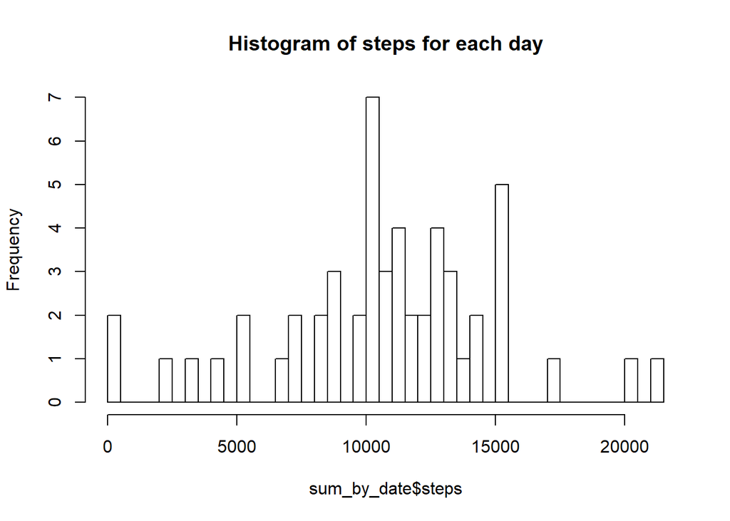

```r
hist(sum_by_date$steps, breaks = 52, main = "Histogram of steps for each day")
```

# 3.Calculate and report the mean and median of the total number of steps taken per day

```r
mean(sum_by_date$steps)
```

```
## [1] 10766.19
```

```r
median(sum_by_date$steps)
```

```
## [1] 10765
```

# What is the average daily activity pattern?

# 1. Make a time series plot (i.e. type = “l”) of the 5-minute interval (x-axis) and the average number of steps taken, averaged across all days (y-axis)

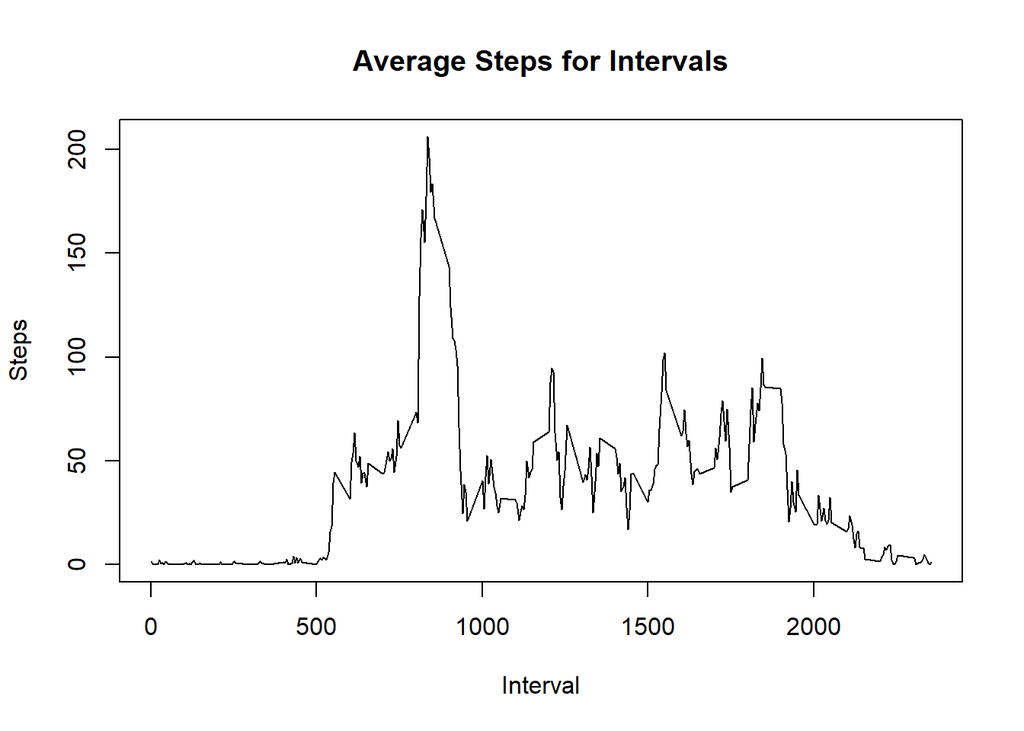

```r
data1_grouped_interval <- group_by(data1, interval)
data1_grouped_date$date <- 0
mean_by_interval <- summarize(data1_grouped_interval, mean(steps))
 colnames(mean_by_interval) <- c("interval", "steps")
plot(mean_by_interval$steps~ mean_by_interval$interval, type="l",ylab = "Steps", xlab= "Interval", main="Average Steps for Intervals" )
```

# 2.Which 5-minute interval, on average across all the days in the dataset, contains the maximum number of steps?

```r
head(mean_by_interval[rev(order(mean_by_interval$steps)),][1,])
```

```
## # A tibble: 1 × 2
##   interval    steps
##      <int>    <dbl>
## 1      835 206.1698
```

# Note that there are a number of days/intervals where there are missing values (coded as NA). The presence of missing days may introduce bias into some calculations or summaries of the data.